# Exploring the BRFSS data

## Setup

### Load packages

```r
library(ggplot2)
library(dplyr)
```

### Load data

```r
load("brfss2013.RData")
```

## Part 1: Data

This retrospective observational study also known as the Behavioural Risk Factor Surveillance System (BRFSS) began in 1984 and focuses on those who are 18 years or older and live in the USA. BRFSS is deemed a retrospective observational study as it queries those who participated in regards to their health in the months prior to being contacted by the study. Phone calls are the chosen method to gather data. Respondents that do not qualify to partake in the study and are eliminated if they are using a phone that is anything other than a landline, are not 18 years of age or above and lastly, if they do not reside in college or residential type accommodation. A random adult is then chosen from a contacted household to when these requirements are met. BRFSSA carried out two kind of surveys since 2011, those being, cellular telephone based and landline telephone surveys. There are differences between these two methods of data collection. The BRFSS landline telephone survey obtains data from a randomly selected adult i.e. whomever picks the phone up at the time of the call. The BRFSS cellular telephone survey obtains data from an adult who takes part through a cellular telephone or resides in college or residential type accommodation. The Behavioural Risk Factor Surveillance System is an observational study that does not include random assignment of respondents to the parameters under question. This study is not deemed an experiment and therefore there are restrictions in what conclusions can be made from the data gathered. It is not possible to determine causality from the data, only associated relationships. There are multiple problems with the chosen method of sampling and include differentiations between the population sampled and the disclosed population of the survey. An example being the use of telephones, using this method only limits the sampling area to adults who have access to a landline and resides in college or residential accommodation. Nonresponse bias is presented through those who are contacted by not answering the phone call or being unable to do so. There is also potential for differences in demographics to happen through more cases of a particular type of person answering the phone and taking the questionnaire. In 2013 the data depicts that more females, and those who are more wealthy and white responded to the questionnaire than what is present in the population of interest. There were no steps taken to normalise the quantity of respondents according to their state of residence. The segment of those who answered the phones from each state is different than they would be in the population of interest. These examples highlight how the sample population may not be truly representative of the target population. Other issues arise from how the questionnaire was asked. Respondents may be biased in their answers, their memory of their health over the past months may not be precise or correct. Respondents may also not be truthful in some cases due to the sensitivity of health related questions e.g. a respondent may reveal a number much lower than the truer value if asked how many cigarettes they have smoked in the past week or binge drank in the last month, as examples. Taking these restrictions into consideration and the potential for bias to be introduced in sampling, it is wise to show caution when making robust claims from the data collected by BRFSS. Although there a numerous concerns, there was a large sample size used and is representative of adults residing in the US, therefore the study is generalizable.

## Part 2: Research questions

**Research question 1:** Research Question: Is there any correlation between How Many Times a respondent went Walking, Running, Jogging, Or Swimming and the reported number of days where a respondent felt full of energy (in the past 30 Days.) Also, are there any noticeable differences in this association between genders.

Interest Factor: Exercise is capable of increasing circulation and the heart muscle which will ultimately increase energy levels. I am interested in to see if the reported amount of times a respondent engaged in exercise correlates to overall energy levels.

**Research question 2:** Research Question:Is there any relationship between level of income and overall satisfaction. Is there any observable differences in this correlation between genders.

Interest factor: Any noticeable trends in overall life satisfaction for those who do not live in poverty. I am interested to see if higher levels of income result in a higher level of satisfaction as it said that money doesn’t money buy happiness. I want to test this theory.

## Part 3: Exploratory data analysis

**Research quesion 1:**

```r
q1 <- select(brfss2013, qlhlth2 , sex , exerhmm1) %>%
  filter(!is.na(qlhlth2), !is.na(sex), exerhmm1 <= 12 )
q1 %>% group_by(qlhlth2) %>%
  summary(count=n())
```

```
##     qlhlth2          sex       exerhmm1
##  Min.   : 0.00   Male  :4   Min.   : 2.0
##  1st Qu.: 1.50   Female:4   1st Qu.: 3.5
##  Median :12.50              Median : 9.0
##  Mean   :13.38              Mean   : 7.0
##  3rd Qu.:25.00              3rd Qu.:10.0
##  Max.   :30.00              Max.   :10.0
```

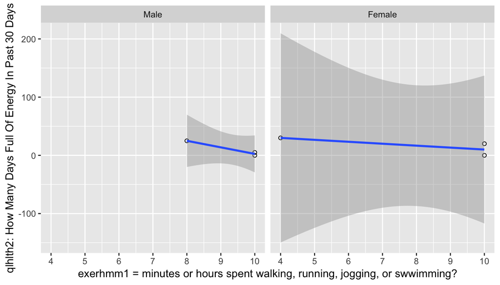

```r
ggplot(data = q1, aes(x = exerhmm1, y = qlhlth2)) +
  geom_point(shape=1) +
  geom_smooth(method=lm)   +
  scale_x_continuous(limits = c(4,10), breaks = 4:10) +
  facet_grid(. ~  sex) +
  xlab("exerhmm1 = minutes or hours spent walking, running, jogging, or swwimming?") +
ylab ("qlhlth2: How Many Days Full Of Energy In Past 30 Days")
```

**The results of the survey depict no significant correlation between the number of minutes/hours spent exercising and the number of full energetic days reported.

**Research quesion 2:**

```r
q2 <- select(brfss2013, lsatisfy , sex, income2) %>%
filter(!is.na(lsatisfy), !is.na(sex), !is.na(income2))
q2 %>% group_by(lsatisfy) %>%
summarise(count=n())
```

```
## # A tibble: 4 x 2
##   lsatisfy          count
##   <fct>             <int>
## 1 Very satisfied     4290
## 2 Satisfied          4418
## 3 Dissatisfied        490
## 4 Very dissatisfied   134
```

```r
q2 %>% group_by(income2) %>%
summarise(count=n())
```

```
## # A tibble: 8 x 2
##   income2           count
##   <fct>             <int>
## 1 Less than $10,000   864
## 2 Less than $15,000   985
## 3 Less than $20,000  1039
## 4 Less than $25,000  1044
## 5 Less than $35,000  1179
## 6 Less than $50,000  1274
## 7 Less than $75,000  1241
## 8 $75,000 or more    1706
```

```r
q2 %>% group_by(sex) %>%
summarise(count=n())
```

```
## # A tibble: 2 x 2
##   sex    count
##   <fct>  <int>
## 1 Male    3418
## 2 Female  5914
```

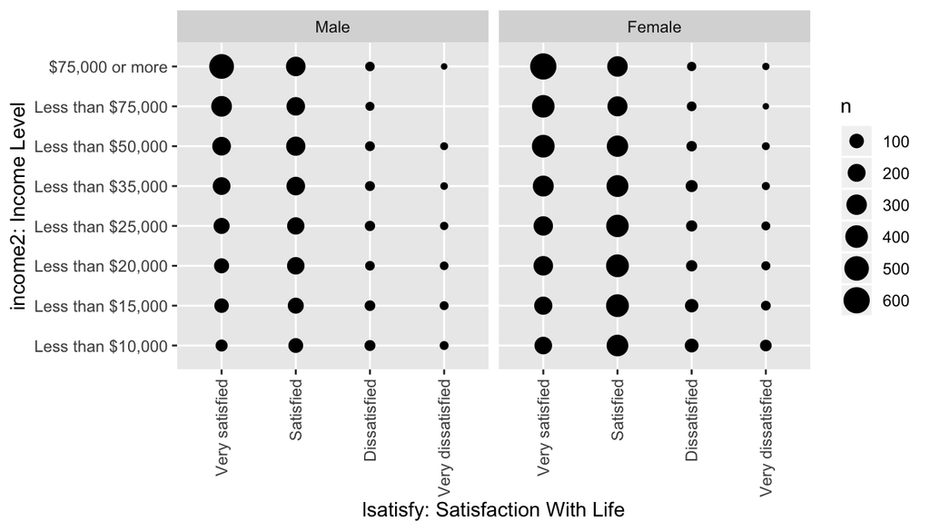

```r
ggplot(data = q2, aes(x = lsatisfy , y = income2 ))+
geom_count () +
theme(axis.text.x = element_text(angle = 90, vjust = 0.5, hjust=1))+
facet_grid(. ~  sex) +
xlab("lsatisfy: Satisfaction With Life") +
ylab ("income2: Income Level")
```

**Research quesion 3:**

```r
q3 <- select(brfss2013, genhlth ,educa) %>%
filter(!is.na(genhlth), !is.na(educa))
q3 %>% group_by(genhlth) %>%
summarise(count=n())
```

```
## # A tibble: 5 x 2
##   genhlth    count
##   <fct>      <int>
## 1 Excellent  85048
## 2 Very good 158500
## 3 Good      149836
## 4 Fair       66390
## 5 Poor       27788
```

```r
q3 %>% group_by(educa) %>%
summarise(count=n())
```

```
## # A tibble: 6 x 2
##   educa                                                         count
##   <fct>                                                         <int>
## 1 Never attended school or only kindergarten                      656
## 2 Grades 1 through 8 (Elementary)                               13223
## 3 Grades 9 though 11 (Some high school)                         27905
## 4 Grade 12 or GED (High school graduate)                       142371
## 5 College 1 year to 3 years (Some college or technical school) 133740
## 6 College 4 years or more (College graduate)                   169667
```

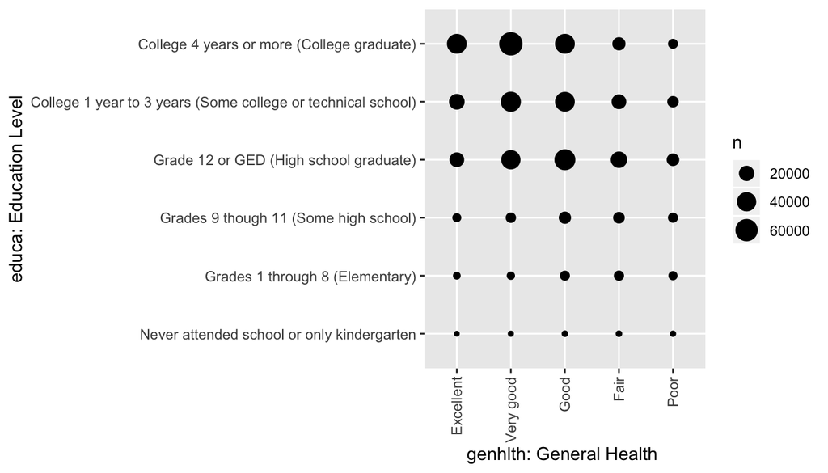

```r
ggplot(data = q3, aes(x = genhlth , y = educa))+
geom_count () +
theme(axis.text.x = element_text(angle = 90, vjust = 0.5, hjust=1))+
xlab("genhlth: General Health ") +
ylab ("educa: Education Level")
```